# Python for Business Analytics: Week 9-10 Review

- Show All Code
- Hide All Code
- View Source

Data Visualization, Hypothesis Testing, and Statistical Analysis

Author

ISM4641

Published

April 21, 2025

## Introduction

This document provides a comprehensive review of the material covered in Weeks 9-10 of our Python for Business Analytics course. We’ll revisit key concepts from data visualization with Matplotlib (Week 9) and statistical analysis, including hypothesis testing and confidence intervals (Week 10).

## Week 9: Data Visualization with Matplotlib

### Key Concepts

1. **Importance of Data Visualization in Business Analytics**
   - Enhances information processing and pattern recognition
   - Facilitates clearer communication with stakeholders
   - Supports informed decision-making
2. **Matplotlib Fundamentals**
   - Object-oriented interface using Figure and Axes objects
   - Integration with NumPy and Pandas
   - Basic syntax and standard imports

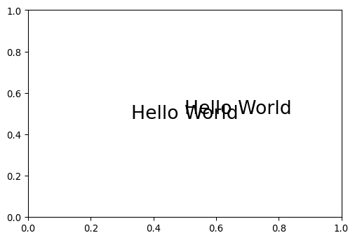

   ```python
   import matplotlib.pyplot as plt
   import numpy as np
   import pandas as pd

   # Create a figure and axes
   fig, ax = plt.subplots(figsize=(6, 4))

   # add hello world text
   ax.text(0.5, 0.5, 'Hello World', fontsize=20)
   ax.text(0.5, 0.5, 'Hello World', fontsize=20, ha='center', va='center')
   ```

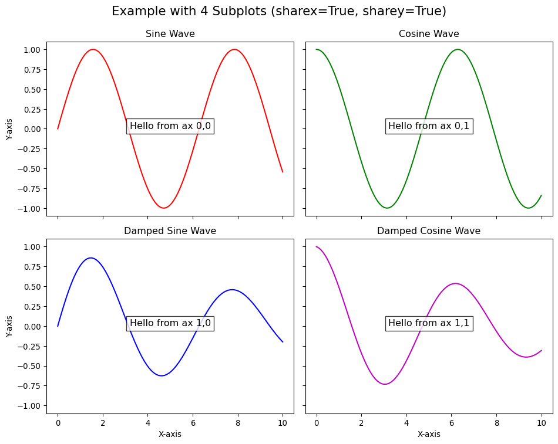

   ```python
   import matplotlib.pyplot as plt
   import numpy as np

   # Create a figure with 2x2 subplots, sharing x and y axes
   fig, axes = plt.subplots(nrows=2, ncols=2, figsize=(10, 8),
                            sharex=True, sharey=True)  # Share both x and y axes

   # Generate some sample data
   x = np.linspace(0, 10, 100)
   y1 = np.sin(x)
   y2 = np.cos(x)
   y3 = np.sin(x) * np.exp(-0.1*x)
   y4 = np.cos(x) * np.exp(-0.1*x)

   # Plot data on each subplot and add text
   axes[0, 0].plot(x, y1, 'r-')
   axes[0, 0].text(5, 0, "Hello from ax 0,0", ha='center', fontsize=12,
                   bbox=dict(facecolor='white', alpha=0.8))

   axes[0, 1].plot(x, y2, 'g-')
   axes[0, 1].text(5, 0, "Hello from ax 0,1", ha='center', fontsize=12,
                   bbox=dict(facecolor='white', alpha=0.8))

   axes[1, 0].plot(x, y3, 'b-')
   axes[1, 0].text(5, 0, "Hello from ax 1,0", ha='center', fontsize=12,
                   bbox=dict(facecolor='white', alpha=0.8))

   axes[1, 1].plot(x, y4, 'm-')
   axes[1, 1].text(5, 0, "Hello from ax 1,1", ha='center', fontsize=12,
                   bbox=dict(facecolor='white', alpha=0.8))

   # Add titles to each subplot
   axes[0, 0].set_title('Sine Wave')
   axes[0, 1].set_title('Cosine Wave')
   axes[1, 0].set_title('Damped Sine Wave')
   axes[1, 1].set_title('Damped Cosine Wave')

   # Add a main title for the entire figure
   fig.suptitle('Example with 4 Subplots (sharex=True, sharey=True)', fontsize=16)

   # Only the bottom subplots need x-labels (due to sharex=True)
   axes[1, 0].set_xlabel('X-axis')
   axes[1, 1].set_xlabel('X-axis')

   # Only the left subplots need y-labels (due to sharey=True)
   axes[0, 0].set_ylabel('Y-axis')
   axes[1, 0].set_ylabel('Y-axis')

   # Adjust spacing between subplots
   plt.tight_layout()
   plt.subplots_adjust(top=0.9)  # Make room for the suptitle

   # Display the plot
   plt.show()
   ```

3. **Common Plot Types for Business Data**
   - **Line Plots**: Trends over time (e.g., monthly sales data)
   - **Bar Charts**: Comparing categories (e.g., department performance)
   - **Horizontal Bar Charts**: Long category names (e.g., product revenue)
   - **Pie Charts**: Composition analysis (e.g., market share)
   - **Scatter Plots**: Relationships between variables (e.g., marketing spend vs. revenue)
   - **Histograms**: Distribution analysis (e.g., customer purchase amounts)
4. **Plot Customization**
   - Titles, labels, and legends
   - Colors, line styles, and markers
   - Tick customization
   - Annotations to highlight key insights
5. **Multiple Plots and Dashboards**
   - Creating subplots for comparative analysis
   - Arranging multiple visualizations for comprehensive insights
6. **Integration with Pandas**
   - Direct plotting from DataFrames
   - Simplified workflow for data analysis and visualization
7. **Best Practices for Business Visualizations**
   - Choose appropriate plot types for different data scenarios
   - Maintain clarity and simplicity
   - Ensure honest representation of data
   - Consider accessibility (e.g., colorblind-friendly palettes)
   - Focus on storytelling and highlighting key insights